# multiclass_svm

### Multiclass Support Vector Machines

In this exercise you will:

- implement a fully-vectorized loss function for the mulri-class SVM
- implement the fully-vectorized expression for its analytic gradient
- check your implementation using numerical gradient
- use a validation set to tune the learning rate and regularization strength
- optimize the loss function with SGD
- visualize the final learned parameters

```python
# Run some setup code for this notebook.

import random
import numpy as np
from data_utils import load_CIFAR10
import matplotlib.pyplot as plt

# This is a bit of magic to make matplotlib figures appear inline in the
# notebook rather than in a new window.
%matplotlib inline
plt.rcParams['figure.figsize'] = (10.0, 8.0) # set default size of plots
plt.rcParams['image.interpolation'] = 'nearest'
plt.rcParams['image.cmap'] = 'gray'

# Some more magic so that the notebook will reload external python modules;
# see http://stackoverflow.com/questions/1907993/autoreload-of-modules-in-ipython
%load_ext autoreload
%autoreload 2
```

```
The autoreload extension is already loaded. To reload it, use:
  %reload_ext autoreload
```

### CIFAR-10 Data Loading and Preprocessing

Open up a terminal window and navigate to the datasets folder inside the hw3 folder. Run the get_datasets.sh script. On my Mac, I just type in ./get_datasets.sh at the shell prompt. A new folder called cifar_10_batches_py will be created and it will contain 50000 labeled images for training and 10000 labeled images for testing. The function further partitions the 50000 training images into a train set and a validation set for selection of hyperparameters. We have provided a function to read this data in **data_utils.py**. Each image is a 32×32 array of RGB triples. It is preprocessed by subtracting the mean image from all images. We flatten each image into a 1-dimensional array of size 3072 (i.e., 32×32×3). Then a 1 is appended to the front of that vector to handle the intercept term. So the training set is a numpy matrix of size 49000×3073, the validation set is a matrix of size 1000×3073 and the set-aside test set is of size 10000×3073. We also have a random sample of 500 images from the training data to serve as a development set or dev set to test our gradient and loss function implementations.

```python
import data_utils

# Get the CIFAR-10 data broken up into train, validation and test sets

X_train, y_train, X_val, y_val, X_dev, y_dev, X_test, y_test = data_utils.get_CIFAR10_data()
```

```
Train data shape:  (49000, 32, 32, 3)
Train labels shape:  (49000,)
Validation data shape:  (1000, 32, 32, 3)
Validation labels shape:  (1000,)
Test data shape:  (10000, 32, 32, 3)
Test labels shape:  (10000,)
Training data shape:  (49000, 3072)
Validation data shape:  (1000, 3072)
Test data shape:  (10000, 3072)
dev data shape:  (500, 3072)
Training data shape with bias term:  (49000, 3073)
Validation data shape with bias term:  (1000, 3073)
Test data shape with bias term:  (10000, 3073)
Devset data shape with bias term:  (500, 3073)
```

### SVM Classifier

```python
# Evaluate the naive implementation of the loss we provided for you:
from linear_svm import svm_loss_naive
import time

# generate a random SVM coefficient matrix of small numbers
theta = np.random.randn(3073, 10) * 0.0001

loss, grad = svm_loss_naive(theta, X_train, y_train, 0.00001)
print 'loss: %f' % (loss, )
print 'grad: ', grad
```

```
loss: 9.052794
grad:  [[ -9.88308523e+00  -5.84410820e+00   3.77023931e+00 ...,   4.03124457e+00
   -1.94167222e+01  -3.72060531e+01]
 [ -2.02765207e+01  -2.08727965e+00   3.07685108e+00 ...,   3.28984595e+00
   -3.05800167e+01  -4.19080800e+01]
 [ -3.98990897e+01  -3.32526556e+00   1.49027597e+01 ...,   4.64905269e+00
   -5.04137800e+01  -5.28890253e+01]
 ...,
 [ -7.59075657e+00  -6.79429604e+00  -1.28886251e+00 ...,  -3.85842518e+00
    1.13506278e+01  -1.08492958e+01]
 [ -2.01461403e+01  -1.33936508e+01   6.26813024e+00 ...,   1.14531124e+01
   -8.39535618e+00  -1.50084295e+01]
 [  2.51224491e-02   1.48571449e-02  -1.03877560e-02 ...,  -1.40204096e-02
   -3.10816330e-02  -2.14285729e-03]]
```

```python
# Once you've implemented the gradient, recompute it with the code below
# and gradient check it with the function we provided for you

# Compute the loss and its gradient at theta.
loss, grad = svm_loss_naive(theta, X_dev, y_dev, 0.0)

# Numerically compute the gradient along several randomly chosen dimensions, and
# compare them with your analytically computed gradient. The numbers should match
# almost exactly along all dimensions.
from gradient_check import grad_check_sparse
f = lambda th: svm_loss_naive(th, X_dev, y_dev, 0.0)[0]
grad_numerical = grad_check_sparse(f, theta, grad)

# do the gradient check once again with regularization turned on
# you didn't forget the regularization gradient did you?
loss, grad = svm_loss_naive(theta, X_dev, y_dev, 1e2)
f = lambda w: svm_loss_naive(theta, X_dev, y_dev, 1e2)[0]
grad_numerical = grad_check_sparse(f, theta, grad)
```

```
numerical: 5.131971 analytic: 5.131971, relative error: 2.201248e-11
numerical: -7.410936 analytic: -7.434171, relative error: 1.565195e-03
numerical: 5.190522 analytic: 5.190522, relative error: 3.131233e-11
numerical: -7.831006 analytic: -7.831006, relative error: 8.311738e-12
numerical: 20.570386 analytic: 20.570386, relative error: 5.982765e-12
numerical: -13.661142 analytic: -13.661142, relative error: 3.781269e-13
numerical: -31.819890 analytic: -31.819890, relative error: 1.475018e-11
numerical: 21.329251 analytic: 21.329251, relative error: 8.848783e-12
numerical: 2.903292 analytic: 2.892183, relative error: 1.916888e-03
numerical: 23.530376 analytic: 23.530376, relative error: 4.689115e-12
numerical: -18.695896 analytic: -18.695896, relative error: 2.231299e-11
numerical: 0.016926 analytic: 0.016926, relative error: 1.057404e-08
numerical: 21.467118 analytic: 21.467118, relative error: 1.088771e-11
numerical: 23.579798 analytic: 23.579798, relative error: 1.757531e-11
numerical: -47.905829 analytic: -47.905829, relative error: 7.583342e-12
numerical: -0.410891 analytic: -0.410891, relative error: 9.378080e-11
numerical: -3.693755 analytic: -3.693755, relative error: 3.947522e-11
numerical: -23.368520 analytic: -23.368520, relative error: 4.239354e-13
numerical: 20.476220 analytic: 20.476220, relative error: 2.210767e-11
numerical: 0.548112 analytic: 0.548112, relative error: 1.451620e-10
```

```python
# Next implement the function svm_loss_vectorized; for now only compute the loss;
# we will implement the gradient in a moment.
tic = time.time()
loss_naive, grad_naive = svm_loss_naive(theta, X_dev, y_dev, 0.00001)
toc = time.time()
print 'Naive loss: %e computed in %fs' % (loss_naive, toc - tic)

from linear_svm import svm_loss_vectorized
tic = time.time()
loss_vectorized, _ = svm_loss_vectorized(theta, X_dev, y_dev, 0.00001)
toc = time.time()
print 'Vectorized loss: %e computed in %fs' % (loss_vectorized, toc - tic)

# The losses should match but your vectorized implementation should be much faster.
print 'difference: %f' % (loss_naive - loss_vectorized)
```

```
Naive loss: 9.037231e+00 computed in 0.145620s
Vectorized loss: 9.037231e+00 computed in 0.011016s
difference: -0.000000
```

### Vectorized version of the gradient computation

Complete the implementation of svm_loss_vectorized, and compute the gradient of the loss function in a vectorized way.

```python
# The naive implementation and the vectorized implementation should match, but
# the vectorized version should still be much faster.
tic = time.time()
_, grad_naive = svm_loss_naive(theta, X_dev, y_dev, 0.00001)
toc = time.time()
print 'Naive loss and gradient: computed in %fs' % (toc - tic)

tic = time.time()
_, grad_vectorized = svm_loss_vectorized(theta, X_dev, y_dev, 0.00001)
toc = time.time()
print 'Vectorized loss and gradient: computed in %fs' % (toc - tic)

# The loss is a single number, so it is easy to compare the values computed
# by the two implementations. The gradient on the other hand is a matrix, so
# we use the Frobenius norm to compare them.
difference = np.linalg.norm(grad_naive - grad_vectorized, ord='fro')
print 'difference: %f' % difference
```

```
Naive loss and gradient: computed in 0.115488s
Vectorized loss and gradient: computed in 0.003834s
difference: 0.000000
```

```python
# In the file linear_classifier.py, we have implemented SGD in the function
# LinearClassifier.train() and you can run it with the code below.
from linear_classifier import LinearSVM
svm = LinearSVM()
tic = time.time()
loss_hist = svm.train(X_train, y_train, learning_rate=1e-7, reg=5e4,
                      num_iters=1500, verbose=True)
toc = time.time()
print 'That took %fs' % (toc - tic)
```

```
iteration 0 / 1500: loss 788.622095
iteration 100 / 1500: loss 286.590723
iteration 200 / 1500: loss 107.950116
iteration 300 / 1500: loss 42.566482
iteration 400 / 1500: loss 18.270922
iteration 500 / 1500: loss 10.309048
iteration 600 / 1500: loss 7.069572
iteration 700 / 1500: loss 6.223367
iteration 800 / 1500: loss 5.570071
iteration 900 / 1500: loss 5.458083
iteration 1000 / 1500: loss 5.773842
iteration 1100 / 1500: loss 5.106794
iteration 1200 / 1500: loss 5.846402
iteration 1300 / 1500: loss 4.991423
iteration 1400 / 1500: loss 5.168509
That took 4.682455s
```

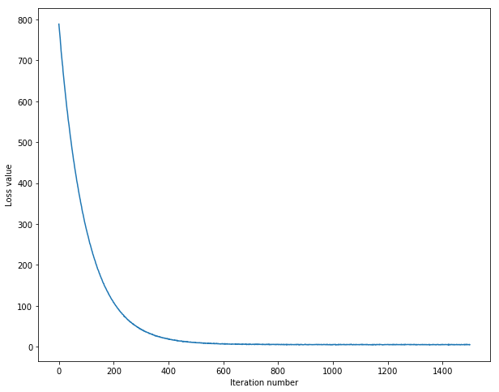

```python
# A useful debugging strategy is to plot the loss as a function of
# iteration number:
plt.plot(loss_hist)
plt.xlabel('Iteration number')
plt.ylabel('Loss value')
plt.show()
```

### Prediction with an SVM

Compute $\theta^T x$ for a new example $x$ and pick the class with the highest score.

```python
# Write the LinearSVM.predict function and evaluate the performance on both the
# training and validation set
y_train_pred = svm.predict(X_train)
print 'training accuracy: %f' % (np.mean(y_train == y_train_pred), )
y_val_pred = svm.predict(X_val)
print 'validation accuracy: %f' % (np.mean(y_val == y_val_pred), )
```

```
training accuracy: 0.369531
validation accuracy: 0.370000
```

```python
# Use the validation set to tune hyperparameters (regularization strength and
# learning rate). You should experiment with different ranges for the learning
# rates and regularization strengths; if you are careful you should be able to
# get a classification accuracy of about 0.38 or higher on the validation set.

learning_rates = [1e-8, 5e-8, 1e-7, 5e-7, 1e-6]
regularization_strengths = [1e4, 5e4, 1e5, 5e5]

# results is dictionary mapping tuples of the form
# (learning_rate, regularization_strength) to tuples of the form
# (training_accuracy, validation_accuracy). The accuracy is simply the fraction
# of data points that are correctly classified.
results = {}
best_val = -1   # The highest validation accuracy that we have seen so far.
best_svm = None # The LinearSVM object that achieved the highest validation rate.

################################################################################
# TODO:                                                                        #
# Write code that chooses the best hyperparameters by tuning on the validation #
# set. For each combination of hyperparameters, train a linear SVM on the      #
# training set, compute its accuracy on the training and validation sets, and  #
# store these numbers in the results dictionary. In addition, store the best   #
# validation accuracy in best_val and the LinearSVM object that achieves this  #
# accuracy in best_svm.                                                        #
#                                                                              #
# Hint: You should use a small value for num_iters as you develop your         #
# validation code so that the SVMs don't take much time to train; once you are #
# confident that your validation code works, you should rerun the validation   #
# code with a larger value for num_iters.                                      #
################################################################################
svm = LinearSVM()
best_lr = 0
best_reg = 0

for l in learning_rates:
    for r in regularization_strengths:
        svm.train(X_train, y_train, learning_rate=l, reg=r,
                      num_iters=200, verbose=True)
        results[(l,r)] = np.mean(y_train == y_train_pred), np.mean(y_val == y_val_pred)
        y_train_pred = svm.predict(X_train)
        y_val_pred = svm.predict(X_val)
        results[(l,r)] = np.mean(y_train == y_train_pred), np.mean(y_val == y_val_pred)
        if (np.mean(y_val == y_val_pred)) > best_val:
            best_val = np.mean(y_val == y_val_pred)
            best_svm = svm
            best_lr = l
            best_reg = r

#try more num_iters
best_svm.train(X_train, y_train, learning_rate=best_lr, reg=best_reg,
                      num_iters=1500, verbose=True)
y_val_pred = svm.predict(X_val)
print  'best validation accuracy achieved during cross-validation: %f after training with more iterations' % np.mean(y_val == y_val_pred)

################################################################################
#                              END OF YOUR CODE                                #
################################################################################

# Print out results.
for lr, reg in sorted(results):
    train_accuracy, val_accuracy = results[(lr, reg)]
    print 'lr %e reg %e train accuracy: %f val accuracy: %f' % (
                lr, reg, train_accuracy, val_accuracy)

print 'best validation accuracy achieved during cross-validation: %f' % best_val
```

```
iteration 0 / 200: loss 173.701357
iteration 100 / 200: loss 165.626764
iteration 0 / 200: loss 750.401181
iteration 100 / 200: loss 676.802368
iteration 0 / 200: loss 1213.386493
iteration 100 / 200: loss 995.233656
iteration 0 / 200: loss 4032.731498
iteration 100 / 200: loss 1482.248802
iteration 0 / 200: loss 17.437529
iteration 100 / 200: loss 14.784171
iteration 0 / 200: loss 49.700130
iteration 100 / 200: loss 32.131023
iteration 0 / 200: loss 37.922869
iteration 100 / 200: loss 17.448692
iteration 0 / 200: loss 29.722412
iteration 100 / 200: loss 6.863674
iteration 0 / 200: loss 5.805148
iteration 100 / 200: loss 5.550087
iteration 0 / 200: loss 5.554916
iteration 100 / 200: loss 5.264505
iteration 0 / 200: loss 5.719896
iteration 100 / 200: loss 5.146126
iteration 0 / 200: loss 8.036575
iteration 100 / 200: loss 6.867642
iteration 0 / 200: loss 5.463844
iteration 100 / 200: loss 5.721927
iteration 0 / 200: loss 6.215156
iteration 100 / 200: loss 5.776584
iteration 0 / 200: loss 6.446641
iteration 100 / 200: loss 5.982441
iteration 0 / 200: loss 9.355713
iteration 100 / 200: loss 7.570936
iteration 0 / 200: loss 6.112632
iteration 100 / 200: loss 5.087560
iteration 0 / 200: loss 6.772428
iteration 100 / 200: loss 5.996242
iteration 0 / 200: loss 7.581867
iteration 100 / 200: loss 7.781187
iteration 0 / 200: loss 10.191039
iteration 100 / 200: loss 9.331066
```

[output cut: 22 more lines]

```
lr 5.000000e-08 reg 1.000000e+05 train accuracy: 0.363490 val accuracy: 0.374000
lr 5.000000e-08 reg 5.000000e+05 train accuracy: 0.331184 val accuracy: 0.353000
lr 1.000000e-07 reg 1.000000e+04 train accuracy: 0.370408 val accuracy: 0.361000
lr 1.000000e-07 reg 5.000000e+04 train accuracy: 0.373959 val accuracy: 0.384000
lr 1.000000e-07 reg 1.000000e+05 train accuracy: 0.357510 val accuracy: 0.361000
lr 1.000000e-07 reg 5.000000e+05 train accuracy: 0.306347 val accuracy: 0.325000
lr 5.000000e-07 reg 1.000000e+04 train accuracy: 0.359041 val accuracy: 0.356000
lr 5.000000e-07 reg 5.000000e+04 train accuracy: 0.340490 val accuracy: 0.338000
lr 5.000000e-07 reg 1.000000e+05 train accuracy: 0.322612 val accuracy: 0.313000
lr 5.000000e-07 reg 5.000000e+05 train accuracy: 0.249122 val accuracy: 0.274000
lr 1.000000e-06 reg 1.000000e+04 train accuracy: 0.308327 val accuracy: 0.308000
lr 1.000000e-06 reg 5.000000e+04 train accuracy: 0.308673 val accuracy: 0.321000
lr 1.000000e-06 reg 1.000000e+05 train accuracy: 0.258531 val accuracy: 0.294000
lr 1.000000e-06 reg 5.000000e+05 train accuracy: 0.174735 val accuracy: 0.194000
best validation accuracy achieved during cross-validation: 0.384000
```

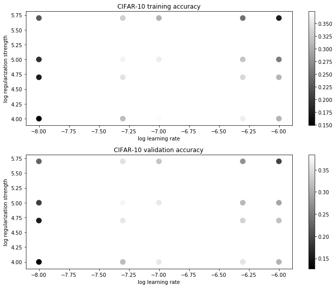

```python
# Visualize the cross-validation results
import math
x_scatter = [math.log10(x[0]) for x in results]
y_scatter = [math.log10(x[1]) for x in results]

# plot training accuracy
marker_size = 100
colors = [results[x][0] for x in results]
plt.subplot(2, 1, 1)
plt.scatter(x_scatter, y_scatter, marker_size, c=colors)
plt.colorbar()
plt.xlabel('log learning rate')
plt.ylabel('log regularization strength')
plt.title('CIFAR-10 training accuracy')

# plot validation accuracy
colors = [results[x][1] for x in results] # default size of markers is 20
plt.subplot(2, 1, 2)
plt.scatter(x_scatter, y_scatter, marker_size, c=colors)
plt.colorbar()
plt.xlabel('log learning rate')
plt.ylabel('log regularization strength')
plt.title('CIFAR-10 validation accuracy')
plt.tight_layout()
plt.show()
```

```python
# Evaluate the best svm on test set
y_test_pred = best_svm.predict(X_test)
test_accuracy = np.mean(y_test == y_test_pred)
print 'linear SVM on raw pixels final test set accuracy: %f' % test_accuracy
```

```
linear SVM on raw pixels final test set accuracy: 0.359900
```

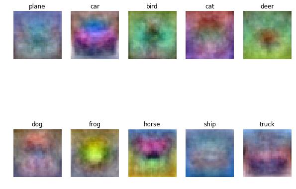

```python
# Visualize the learned weights for each class.
# Depending on your choice of learning rate and regularization strength, these may
# or may not be nice to look at.

theta = best_svm.theta[:-1,:] # strip out the bias
theta = theta.reshape(32, 32, 3, 10)
theta_min, theta_max = np.min(theta), np.max(theta)
classes = ['plane', 'car', 'bird', 'cat', 'deer', 'dog', 'frog', 'horse', 'ship', 'truck']
for i in xrange(10):
  plt.subplot(2, 5, i + 1)

  # Rescale the weights to be between 0 and 255
  thetaimg = 255.0 * (theta[:, :, :, i].squeeze() - theta_min) / (theta_max - theta_min)
  plt.imshow(thetaimg.astype('uint8'))
  plt.axis('off')
  plt.title(classes[i])
```